# Time Series Project Group 09

# 1 Introduction

The objective of this work is to build several models and select the one that best fits the data. Based on the selected model, forecasts will be made using various strategies. The dataset used for this analysis is [Wind Power Production in the US (2001-2022)](https://www.kaggle.com/datasets/henriupton/wind-power-production-us-2001-2023).

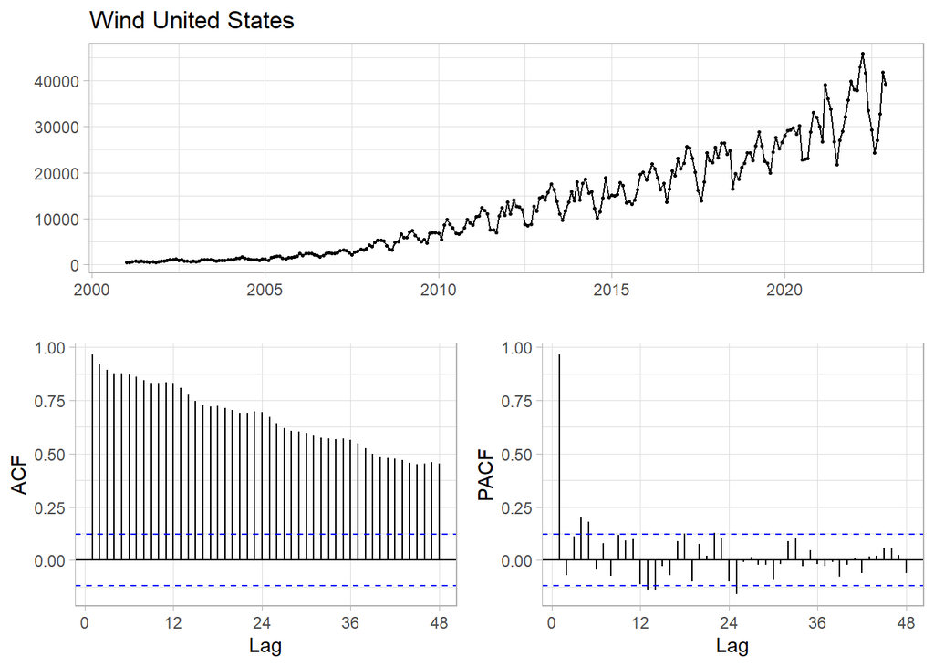

```r
library(astsa)
library(xts)
library(forecast)
library(fpp)
library(ggplot2)
library(lubridate)
library(urca)
library(tseries)
library(Quandl)
library(fable)
library(scales)
library(zoo)
library(tsbox)
library(dplyr)

ts <- read.csv(file.choose())
ts_clean <- ts[c('date','wind_united_states')]

ts_clean$date <- as.character(ts_clean$date)
ts_clean$date <- mdy(paste(ts_clean$date))
ts_clean$date <- as.Date(paste(ts_clean$date, "01", sep = "-"), format = "%Y-%m-%d")


ts_clean1 <- ts(ts_clean$wind_united_states, start = c(year(min(ts_clean$date)), month(min(ts_clean$date))), frequency = 12)


ts_clean1 <- window(ts_clean1, start = c(2001, 1), end = c(2022, 12))



ggtsdisplay(ts_clean1, lag.max = 48, theme = theme_light(), main = "Wind United States")
```

# 2 EDA

First, we will split our dataset into a training set and a test set.

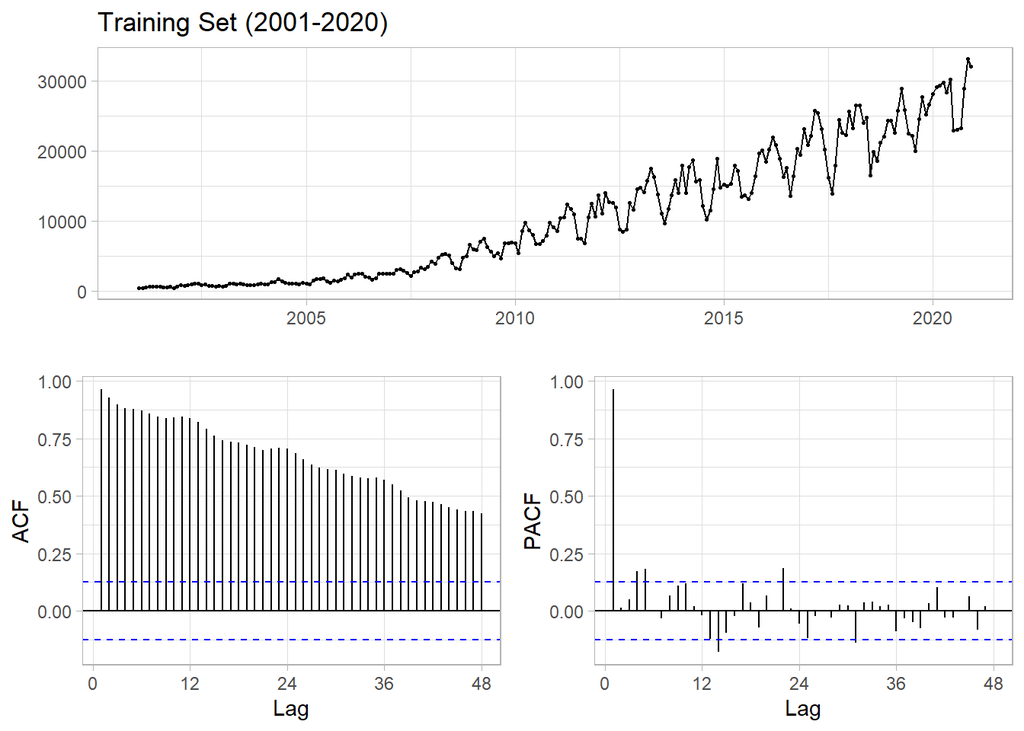

```r
train_set <- window(ts_clean1, start = c(2001, 1), end = c(2020, 12))


test_set <- window(ts_clean1, start = c(2021, 1), end = c(2022, 12))


ggtsdisplay(train_set, lag.max = 48, theme = theme_light(), main= "Training Set (2001-2020)")
```

The time series plot indicates the presence of non-stationarity and heteroscedasticity.

The series shows a clear upward trend over the period from 2001 to 2020, as well as seasonality patterns with regular intervals.

The ACF plot suggests that the autocorrelations decrease slowly as the lag increases, which reinforces the existence of both trend and seasonality in the data. The cyclical pattern in the ACF points to a seasonal component with a defined periodicity.

The PACF plot displays significant spikes at a few initial lags, suggesting the presence of short-term dependencies. This implies the need to consider AR (auto-regressive) terms in the model, while the gradual decline in the ACF also supports the inclusion of MA (moving average) terms.

Following the Box-Jenkins methodology, we should first address heteroscedasticity and perform necessary transformations (e.g., logarithms/BoxCox and differencing) to stabilize the variance and achieve stationarity. Then, we will analyze the ACF and PACF of the transformed series to determine the appropriate SARIMA model.

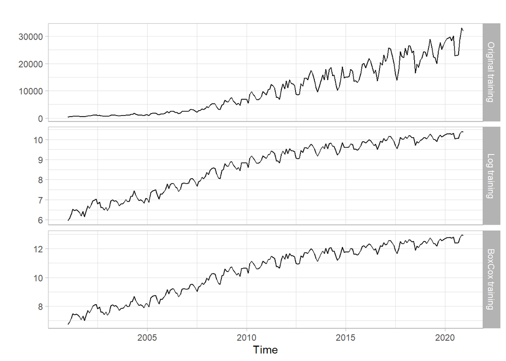

```r
lambda = BoxCox.lambda(train_set)

mts = ts_c(`Original training` = train_set, `Log training` = log(train_set), `BoxCox training` = BoxCox(train_set,
    lambda))

autoplot(mts, facet = T, ylab = NULL) + theme_light()
```

As the variance appears to change over time, indicating heteroscedasticity, the figure compares the plots of the original data, log-transformed, and Box-Cox transformed series.

To address this issue, the Box-Cox transformed version of the data will be used in subsequent analyses to stabilize the variance and ensure more reliable modeling.

# 3 Modelling strategy

We need to determine the number of differences required to make the series stationary.

This involves identifying the number of non-seasonal and seasonal unit roots to account for in the modeling process.

Using the nsdiffs function, we can calculate the necessary seasonal differences.

The analysis shows that the number of seasonal differences required is one (D=1), which corresponds to a 12-month period; therefore, the series will be differenced seasonally once.

```r
train_set_boxcox <- BoxCox(train_set, lambda)

# Definir o objeto 'wind' como uma transformação de 'train_set'
wind <- ts(train_set_boxcox, start = start(train_set), frequency = frequency(train_set))

# Ajustar o ano inicial dinamicamente, com base no comprimento do conjunto
start_year <- start(train_set)[1] + (length(train_set) - length(wind)) / 12

# Atualizar o 'wind' caso seja necessário ajustar o início
wind <- ts(wind, start = c(start_year, 1), frequency = 12)

nsdiffs(wind) #deu 1 entao D=1 no modelo multiplicativo
```

```
[1] 1
```

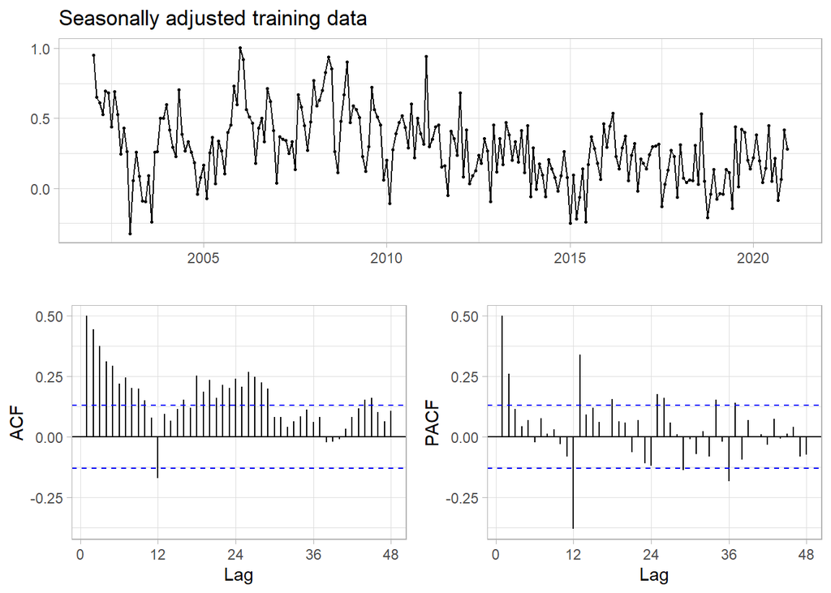

```r
ggtsdisplay(diff(wind, 12), lag.max = 48, theme = theme_light(), main = "Seasonally adjusted training data")
```

The series no longer exhibits seasonality but still appears non-stationary.

Using the ndiffs function, the result indicates that one non-seasonal difference (d=1) is sufficient to achieve stationarity in the series.

```r
ndiffs(diff(wind,12)) #deu 1 entao d=1 no modelo multiplicativo
```

```
[1] 1
```

To verify, we will use the ndiffs function again after applying the differences. It should confirm stationarity by returning a value of 0.

```r
ndiffs(diff(diff(wind,12),1), alpha=0.1)
```

```
[1] 0
```

```r
wind_diff <- diff(diff(wind,12), 1)
```

## 3.1 Identifying the SARIMA model

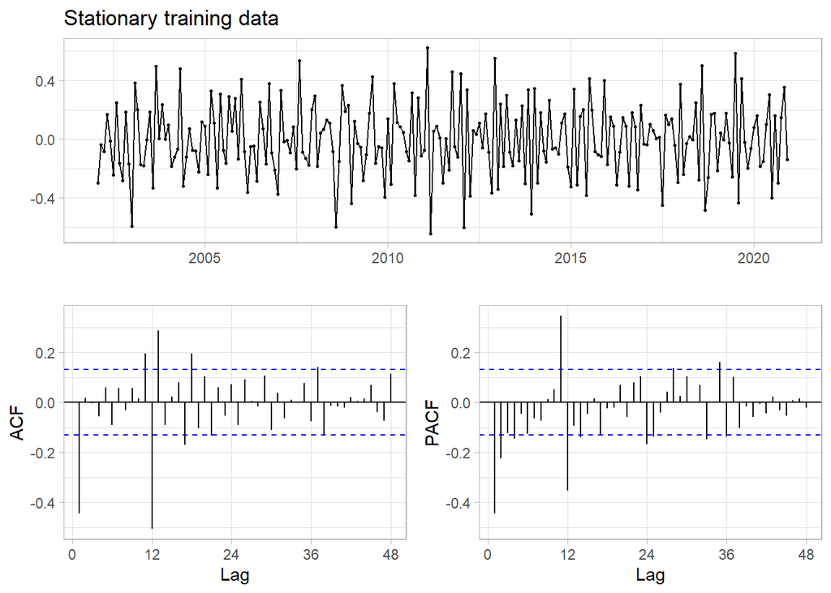

```r
ggtsdisplay(wind_diff, lag.max = 48, theme = theme_light(), main = "Stationary training data")
```

Based on the sample ACF and PACF analysis, we can determine the potential non-seasonal and seasonal AR and MA components for the models.

The ACF indicates the presence of a non-seasonal $\text{MA}(1)$ and a seasonal $\text{MA}(1)$, as significant correlations are observed at lags 1 and 12. This corresponds to $q = 1$ and $Q = 1$. Accordingly, one proposed model is:

- $M_1 = \text{SARIMA}(0, 1, 1) \times (0, 1, 1)_{12}$

The PACF highlights a non-seasonal $\text{AR}(2)$ and a seasonal $\text{AR}(2)$, with notable correlations at lags 1, 12, and 24. This suggests $p = 2$ and $P = 2$. A corresponding model is:

- $M_2 = \text{SARIMA}(2, 1, 0) \times (2, 1, 0)_{12}$

To explore other possibilities, we propose testing mixed configurations that combine the findings from the ACF and PACF analyses. The following models are considered for further evaluation:

- $M_3 = \text{SARIMA}(2, 1, 1) \times (2, 1, 1)_{12}$
- $M_4 = \text{SARIMA}(0, 1, 1) \times (2, 1, 0)_{12}$
- $M_5 = \text{SARIMA}(2, 1, 0) \times (0, 1, 1)_{12}$
- $M_6 = \text{SARIMA}(2, 1, 1) \times (0, 1, 1)_{12}$
- $M_7 = \text{SARIMA}(2, 1, 1) \times (2, 1, 0)_{12}$

Each of these models should be carefully assessed by analyzing the diagnostic plots of residuals and verifying the significance of the estimated parameters to ensure proper fitting.

**M1)** $SARIMA(0,1,1)(0,1,1)_{12}$

```
<><><><><><><><><><><><><><>

Coefficients:
     Estimate     SE  t.value p.value
ma1   -0.5977 0.0711  -8.4036       0
sma1  -0.6988 0.0530 -13.1750       0

sigma^2 estimated as 0.02842617 on 225 degrees of freedom

AIC = -0.6587485  AICc = -0.6585125  BIC = -0.6134849
```

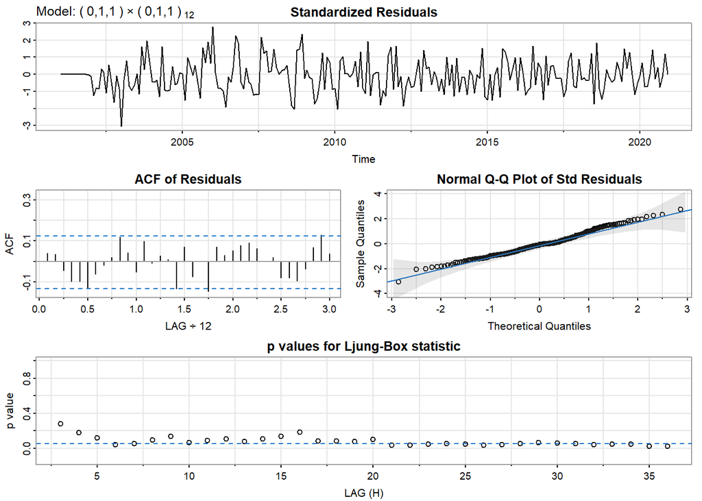

```r
M1 = sarima(wind, 0, 1, 1, 0, 1, 1, 12)
```

- The estimated parameters are statistically significant.
- The residuals exhibit no correlation.
- The Ljung-Box test indicates $p<0.05$ for some lags, indicating that the residuals are dependent.

**M2)** $SARIMA(2,1,0)(2,1,0)_{12}$

```
<><><><><><><><><><><><><><>

Coefficients:
     Estimate     SE  t.value p.value
ar1   -0.5728 0.0647  -8.8548   0e+00
ar2   -0.2353 0.0646  -3.6425   3e-04
sar1  -0.6906 0.0638 -10.8256   0e+00
sar2  -0.3130 0.0657  -4.7680   0e+00

sigma^2 estimated as 0.03047227 on 223 degrees of freedom

AIC = -0.5794202  AICc = -0.5786264  BIC = -0.5039807
```

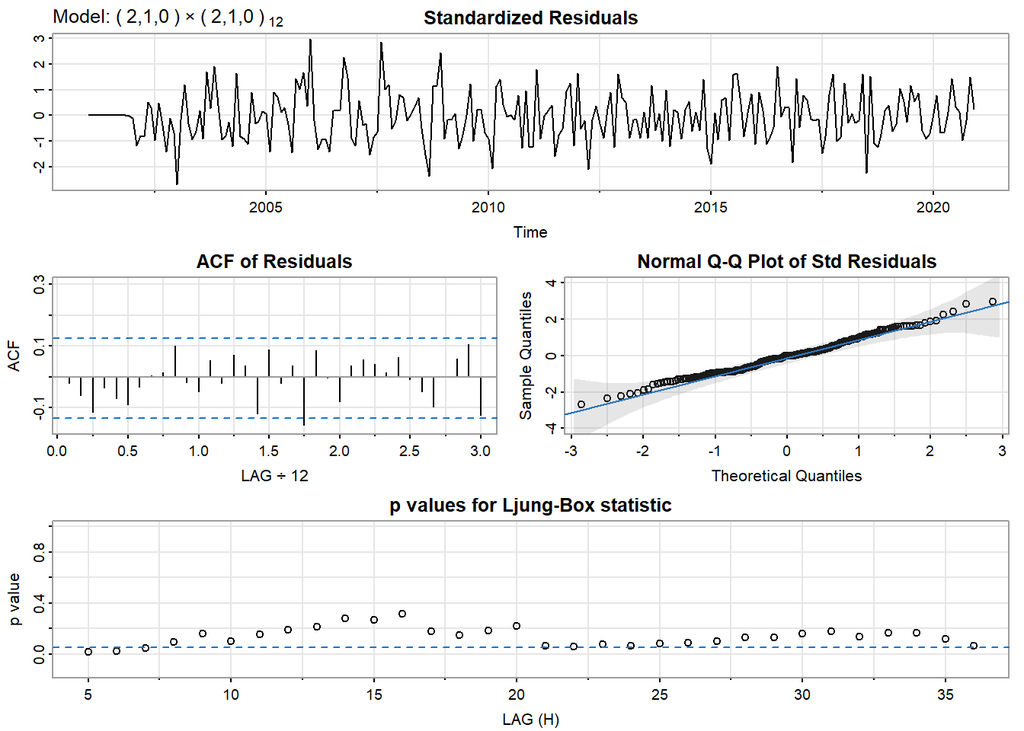

```r
M2 = sarima(wind, 2, 1, 0, 2, 1, 0, 12)
```

- The estimated parameters are statistically significant.
- The residuals exhibit no correlation.
- The Ljung-Box test indicates $p<0.05$ for some lags, indicating that the residuals are dependent.

**M3)** $SARIMA(2,1,1)(2,1,1)_{12}$

```
<><><><><><><><><><><><><><>

Coefficients:
     Estimate     SE  t.value p.value
ar1    0.2551 0.0928   2.7485  0.0065
ar2    0.1565 0.0797   1.9635  0.0508
ma1   -0.8420 0.0581 -14.4904  0.0000
sar1  -0.1289 0.1447  -0.8910  0.3739
sar2   0.0028 0.1140   0.0250  0.9801
sma1  -0.6469 0.1331  -4.8598  0.0000

sigma^2 estimated as 0.02735868 on 221 degrees of freedom

AIC = -0.6577667  AICc = -0.6560847  BIC = -0.5521515
```

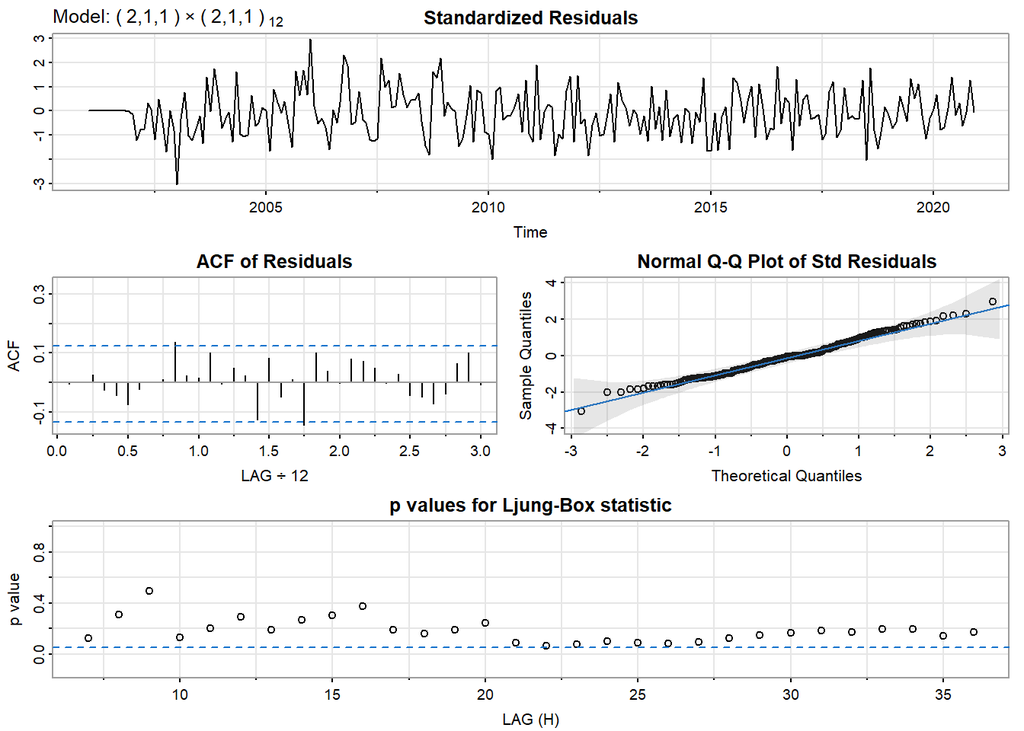

```r
M3 = sarima(wind, 2, 1, 1, 2, 1, 1, 12)
```

- Some of the estimated parameters are not statistically significant.
- The residuals exhibit no correlation.
- The Ljung-Box test indicates $p>0.05$ for all lags, indicating that the residuals are independent.

**M4)** $SARIMA(0,1,1)(2,1,0)_{12}$

```
<><><><><><><><><><><><><><>

Coefficients:
     Estimate     SE  t.value p.value
ma1   -0.6471 0.0609 -10.6236       0
sar1  -0.6794 0.0645 -10.5385       0
sar2  -0.2881 0.0665  -4.3303       0

sigma^2 estimated as 0.02949505 on 224 degrees of freedom

AIC = -0.6215979  AICc = -0.6211238  BIC = -0.5612463
```

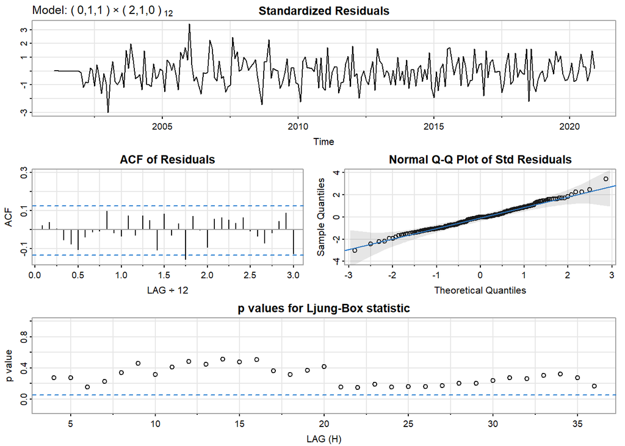

```r
M4 = sarima(wind, 0, 1, 1, 2, 1, 0, 12)
```

- The estimated parameters are statistically significant.
- The residuals exhibit no correlation.
- The Ljung-Box test indicates $p>0.05$ for all lags, indicating that the residuals are independent.

**M5)** $SARIMA(2,1,0)(0,1,1)_{12}$

```
<><><><><><><><><><><><><><>

Coefficients:
     Estimate     SE  t.value p.value
ar1   -0.5022 0.0677  -7.4219  0.0000
ar2   -0.1762 0.0673  -2.6199  0.0094
sma1  -0.7256 0.0535 -13.5697  0.0000

sigma^2 estimated as 0.02917486 on 224 degrees of freedom

AIC = -0.6206433  AICc = -0.6201692  BIC = -0.5602917
```

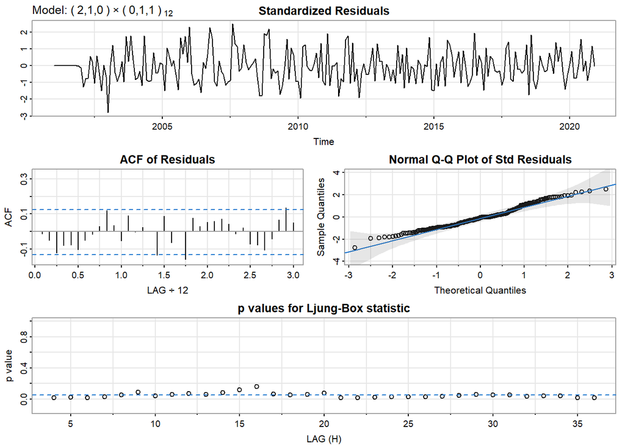

```r
M5 = sarima(wind, 2, 1, 0, 0, 1, 1, 12)
```

- The estimated parameters are statistically significant.
- The residuals exhibit no correlation.
- The Ljung-Box test indicates $p<0.05$ for some lags, indicating that the residuals are dependent.

**M6)** $SARIMA(2,1,1)(0,1,1)_{12}$

```
<><><><><><><><><><><><><><>

Coefficients:
     Estimate     SE  t.value p.value
ar1    0.2715 0.0906   2.9969  0.0030
ar2    0.1586 0.0784   2.0226  0.0443
ma1   -0.8480 0.0570 -14.8707  0.0000
sma1  -0.7209 0.0531 -13.5739  0.0000

sigma^2 estimated as 0.02754853 on 223 degrees of freedom

AIC = -0.6676136  AICc = -0.6668199  BIC = -0.5921742
```

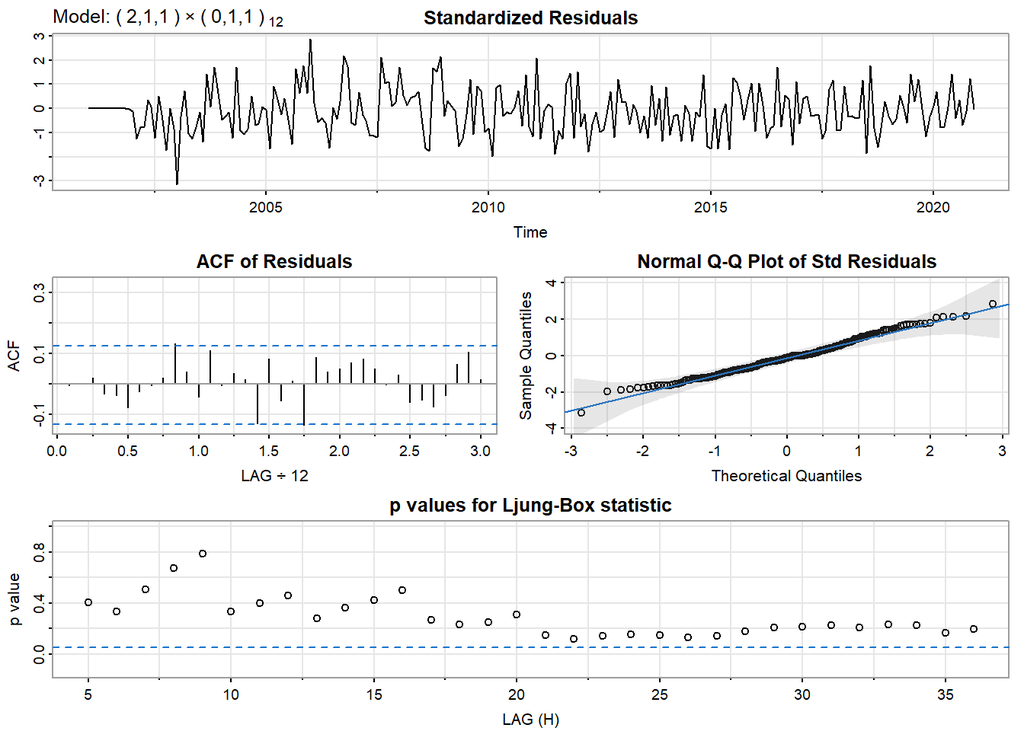

```r
M6 = sarima(wind, 2, 1, 1, 0, 1, 1, 12)
```

- The estimated parameters are statistically significant.
- The residuals exhibit no correlation.
- The Ljung-Box test indicates $p>0.05$ for all lags, indicating that the residuals are independent.

**M7)** $SARIMA(2,1,1)(2,1,0)_{12}$

```
<><><><><><><><><><><><><><>

Coefficients:
     Estimate     SE  t.value p.value
ar1    0.2010 0.1004   2.0020  0.0465
ar2    0.1513 0.0870   1.7392  0.0834
ma1   -0.8378 0.0722 -11.6093  0.0000
sar1  -0.6810 0.0651 -10.4638  0.0000
sar2  -0.2838 0.0678  -4.1828  0.0000

sigma^2 estimated as 0.02906975 on 222 degrees of freedom

AIC = -0.6172911  AICc = -0.6160951  BIC = -0.5267638
```

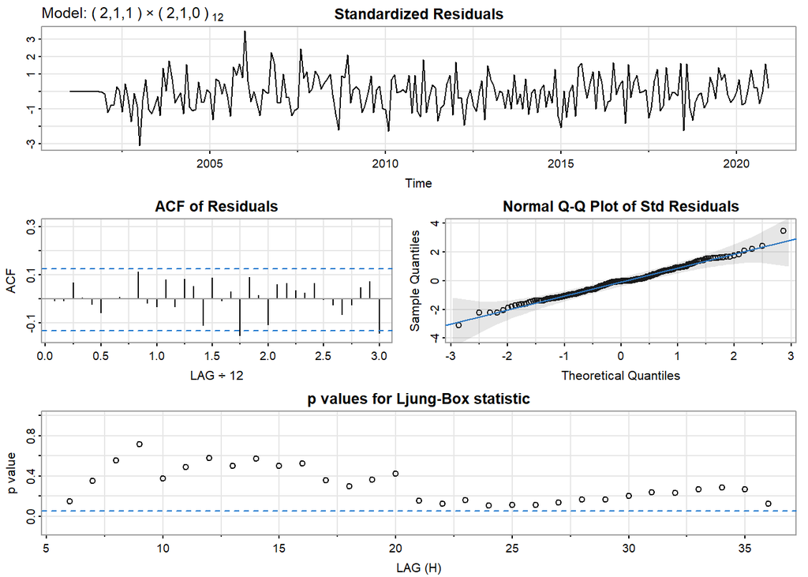

```r
M7 = sarima(wind, 2, 1, 1, 2, 1, 0, 12)
```

- Some of the estimated parameters are not statistically significant.
- The residuals exhibit no correlation.
- The Ljung-Box test indicates $p>0.05$ for all lags, indicating that the residuals are independent.

Recall that **M1, M2, M3, M5** and **M7** are not good candidates.

The best models are **M4** and **M6**.

Another model discovered through experimental analysis and which yielded promising results was the $SARIMA(9,1,0)(0,1,1)_{12}$.

```
<><><><><><><><><><><><><><>

Coefficients:
     Estimate     SE  t.value p.value
ar1   -0.5689 0.0692  -8.2245  0.0000
ar2   -0.3126 0.0781  -4.0020  0.0001
ar3   -0.2459 0.0771  -3.1870  0.0016
ar4   -0.2359 0.0760  -3.1031  0.0022
ar5   -0.2272 0.0763  -2.9799  0.0032
ar6   -0.2688 0.0779  -3.4520  0.0007
ar7   -0.2249 0.0792  -2.8404  0.0049
ar8   -0.1831 0.0778  -2.3526  0.0195
ar9   -0.1465 0.0683  -2.1457  0.0330
sma1  -0.7741 0.0569 -13.6096  0.0000

sigma^2 estimated as 0.02658617 on 217 degrees of freedom

AIC = -0.6425876  AICc = -0.6381007  BIC = -0.4766208
```

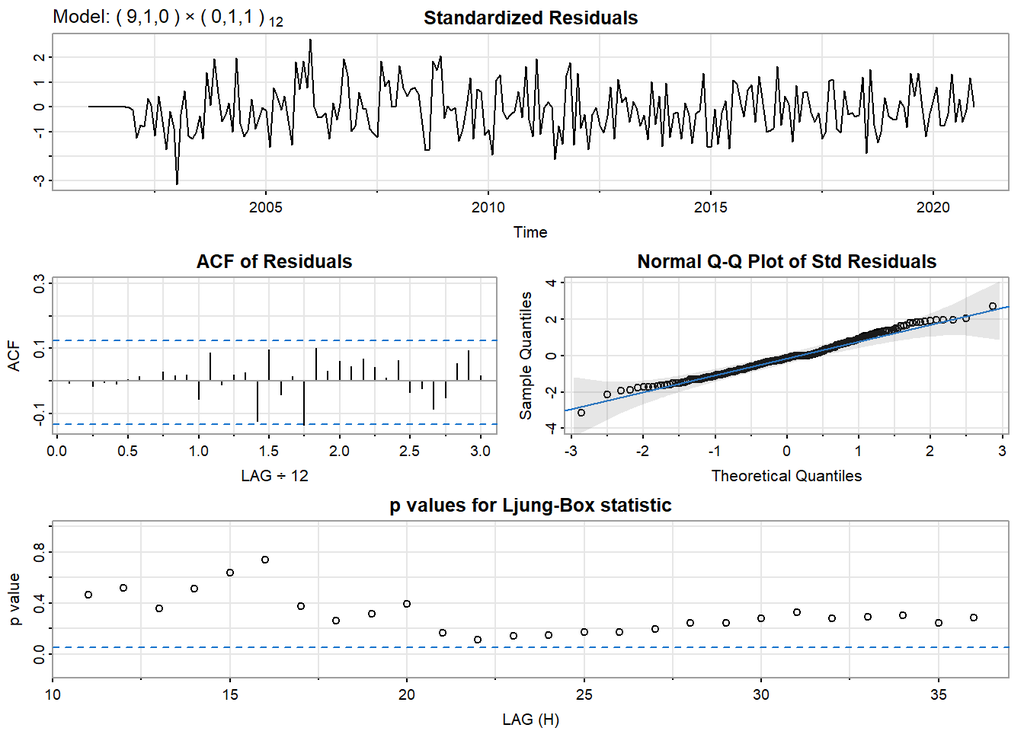

```r
M9= sarima(wind, 9, 1, 0, 0, 1, 1, 12)
```

```r
rbind(M1 = M1$ICs, M2 = M2$ICs, M3 = M3$ICs, M4 = M4$ICs, M5 = M5$ICs,
    M6 = M6$ICs, M7 = M7$ICs, M9=M9$ICs)
```

```
          AIC       AICc        BIC
M1 -0.6587485 -0.6585125 -0.6134849
M2 -0.5794202 -0.5786264 -0.5039807
M3 -0.6577667 -0.6560847 -0.5521515
M4 -0.6215979 -0.6211238 -0.5612463
M5 -0.6206433 -0.6201692 -0.5602917
M6 -0.6676136 -0.6668199 -0.5921742
M7 -0.6172911 -0.6160951 -0.5267638
M9 -0.6425876 -0.6381007 -0.4766208
```

# 4 Forecasting strategies

The forecasting strategies relies on **M4**, **M6** and **M9** specifications, i.e. $SARIMA(0,1,1)(2,1,0)_{12}$, $SARIMA(2,1,1)(0,1,1)_{12}$ and $SARIMA(9,1,0)(0,1,1)_{12}$, respectively.

## 4.1 Forecasting 24-months ahead

- To forecast 24 steps ahead, we will use unique training data, which implies the use of a unique model fit.

```r
# Subset the time series (exclude the last observation)
wind_train <- window(wind)

train_set_boxcox <- BoxCox(train_set, lambda)
test_set <- window(ts_clean1, start = c(2021, 1), end = c(2022, 12))



print(test_set)
```

```
       Jan   Feb   Mar   Apr   May   Jun   Jul   Aug   Sep   Oct   Nov   Dec
2021 30060 26716 39205 36158 33787 26672 21716 27071 28998 32215 35751 39849
2022 38080 37984 43014 45960 41668 33483 29302 24355 27032 32824 41826 39282
```

First, we’ll do the forecasts for *M4*.

```r
#Forecast 24 meses para M4
M4.fit_plots = Arima(train_set_boxcox, order = c(0, 1, 1), seasonal = c(2, 1, 0))
all.equal(M4$fit$coef, M4.fit_plots$coef)
```

```
[1] TRUE
```

```r
#dá true
M4.fct.v1 = forecast(M4.fit_plots, h = 24, level = 95)
```

*Plotting the forecasts*

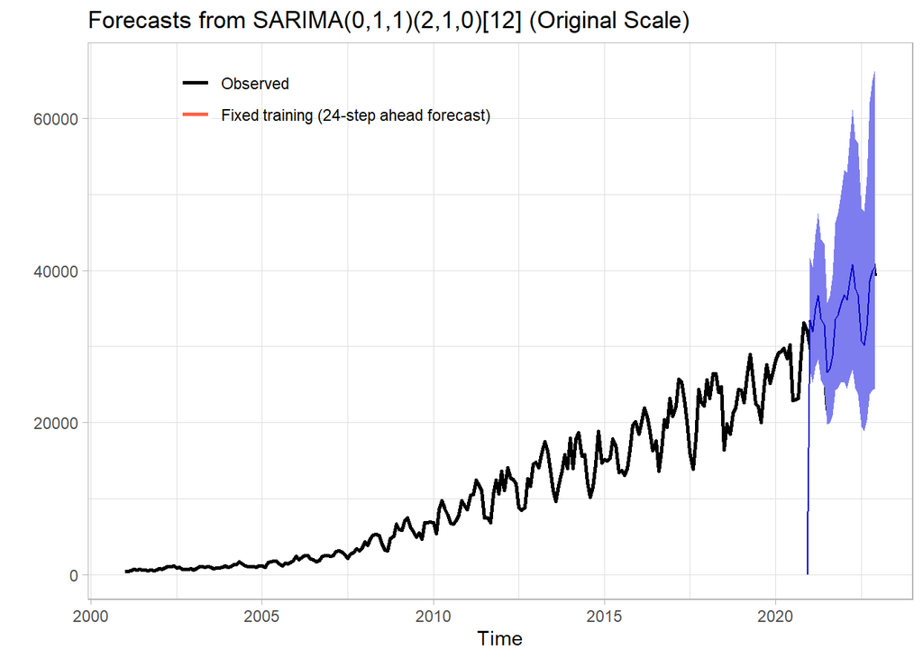

```r
# Reverter a transformação Box-Cox no forecast
M4.fct.v1_original_scale <- M4.fct.v1
M4.fct.v1_original_scale$mean <- InvBoxCox(M4.fct.v1$mean, lambda)

# Reverter a transformação nos limites inferior e superior (linha por linha/coluna)
M4.fct.v1_original_scale$lower <- apply(M4.fct.v1$lower, 2, InvBoxCox, lambda)
M4.fct.v1_original_scale$upper <- apply(M4.fct.v1$upper, 2, InvBoxCox, lambda)


# Criar o gráfico com a série observada e a previsão em escala original
autoplot(ts_c(Observed = ts_clean1,
              `Fixed training (24-step ahead forecast)` = M4.fct.v1_original_scale$mean),
         ylab = NULL, size = 1, main = "Forecasts from SARIMA(0,1,1)(2,1,0)[12] (Original Scale)") +
  scale_color_manual(values = c("black", "tomato")) +
  theme_light() +
  theme(legend.title = element_blank(),
        legend.background = element_blank(),
        legend.position = c(0.3, 0.9)) +
  autolayer(M4.fct.v1_original_scale, showgap = F)
```

*Organising the forecasts and checking the model accuracy.*

```r
# Criando a tabela de previsões para M4 na escala original
fct.tab_M4 <- data.frame(
  Month = as.yearmon(time(test_set)),
  Observed = as.numeric(test_set),  # Converter test_set para numérico
  Forecast = round(M4.fct.v1_original_scale$mean, 2),
  Error = round((as.numeric(test_set) - M4.fct.v1_original_scale$mean), 2),
  Error_PCT = percent(
    (as.vector((as.numeric(test_set) - M4.fct.v1_original_scale$mean) / as.numeric(test_set))),
    accuracy = 0.01
  ),
  Covered_by_CI = between(
    as.numeric(test_set),
    (M4.fct.v1_original_scale$lower),
    (M4.fct.v1_original_scale$upper)
  )
)

# Exibindo a tabela de previsões para M4
knitr::kable(
  fct.tab_M4,
  digits = 2,
  align = "lccccc",
  caption = "Forecasts (24-months ahead) for M4"
)
```

Forecasts (24-months ahead) for M4

| Month | Observed | Forecast | Error | Error_PCT | Covered_by_CI |
| --- | --- | --- | --- | --- | --- |
| jan 2021 | 30060 | 33426.28 | -3366.28 | -11.20% | TRUE |
| fev 2021 | 26716 | 31963.61 | -5247.61 | -19.64% | TRUE |
| mar 2021 | 39205 | 34981.64 | 4223.36 | 10.77% | TRUE |
| abr 2021 | 36158 | 36731.58 | -573.58 | -1.59% | TRUE |
| mai 2021 | 33787 | 33654.87 | 132.13 | 0.39% | TRUE |
| jun 2021 | 26672 | 32833.09 | -6161.09 | -23.10% | TRUE |
| jul 2021 | 21716 | 26607.09 | -4891.09 | -22.52% | TRUE |
| ago 2021 | 27071 | 27046.79 | 24.21 | 0.09% | TRUE |
| set 2021 | 28998 | 28772.17 | 225.83 | 0.78% | TRUE |
| out 2021 | 32215 | 33556.78 | -1341.78 | -4.17% | TRUE |
| nov 2021 | 35751 | 34214.26 | 1536.74 | 4.30% | TRUE |
| dez 2021 | 39849 | 35569.43 | 4279.57 | 10.74% | TRUE |
| jan 2022 | 38080 | 36822.71 | 1257.29 | 3.30% | TRUE |
| fev 2022 | 37984 | 36052.62 | 1931.38 | 5.08% | TRUE |
| mar 2022 | 43014 | 38607.94 | 4406.06 | 10.24% | TRUE |
| abr 2022 | 45960 | 40745.17 | 5214.83 | 11.35% | TRUE |
| mai 2022 | 41668 | 37658.05 | 4009.95 | 9.62% | TRUE |
| jun 2022 | 33483 | 36809.02 | -3326.02 | -9.93% | TRUE |
| jul 2022 | 29302 | 30765.02 | -1463.02 | -4.99% | TRUE |
| ago 2022 | 24355 | 30135.28 | -5780.28 | -23.73% | TRUE |
| set 2022 | 27032 | 32660.16 | -5628.16 | -20.82% | TRUE |
| out 2022 | 32824 | 38600.67 | -5776.67 | -17.60% | TRUE |
| nov 2022 | 41826 | 39932.28 | 1893.72 | 4.53% | TRUE |
| dez 2022 | 39282 | 40536.19 | -1254.19 | -3.19% | TRUE |

```r
# Medidas de precisão para M4 na escala original
accuracy_M4 <- rbind(accuracy(M4.fct.v1_original_scale$mean, test_set))
rownames(accuracy_M4) <- c("Fixed training (24-step ahead forecast)")

knitr::kable(accuracy_M4, digits = 4, align = "ccccccc", caption = "Accuracy measures (24-step ahead forecast) M4")
```

Accuracy measures (24-step ahead forecast) M4

|  | ME | RMSE | MAE | MPE | MAPE | ACF1 | Theil’s U |
| --- | --- | --- | --- | --- | --- | --- | --- |
| Fixed training (24-step ahead forecast) | -653.1129 | 3687.144 | 3081.035 | -3.8037 | 9.7368 | 0.4135 | 0.7 |

Now, we will do the forecasts for *M6*

```r
#Forecast 24 meses para M6
M6.fit_plots = Arima(train_set_boxcox, order = c(2, 1, 1), seasonal = c(0, 1, 1))
all.equal(M6$fit$coef, M6.fit_plots$coef)
```

```
[1] TRUE
```

```r
#dá true
M6.fct.v1 = forecast(M6.fit_plots, h = 24, level = 95)
```

*Plotting the forecasts*

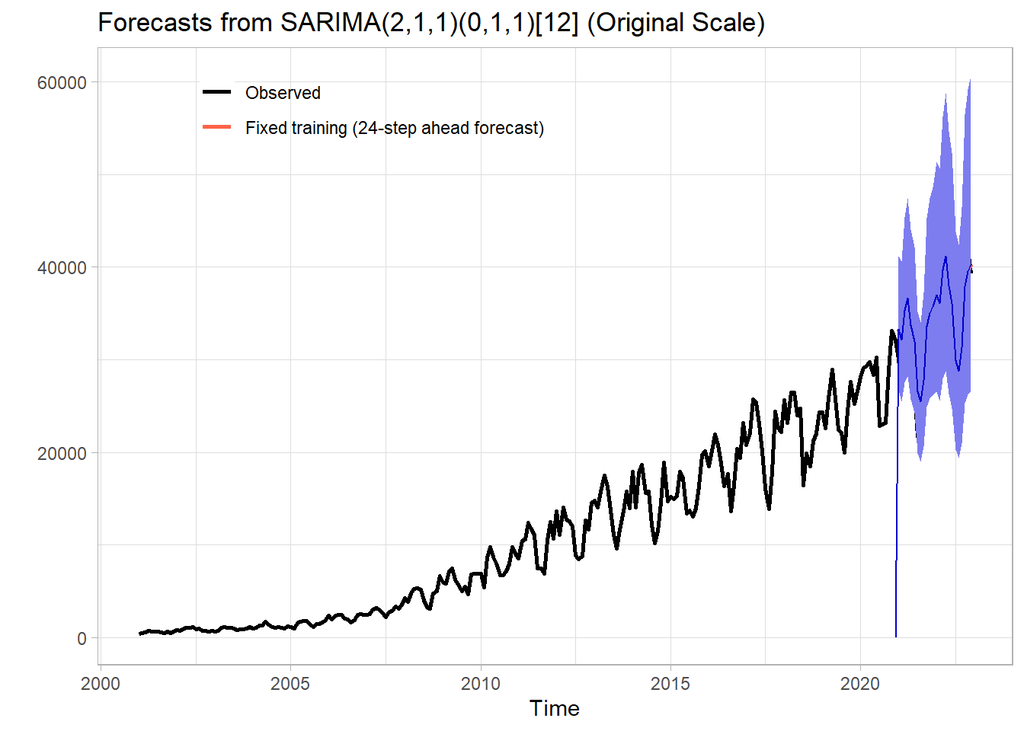

```r
# Reverter a transformação Box-Cox no forecast
M6.fct.v1_original_scale <- M6.fct.v1
M6.fct.v1_original_scale$mean <- InvBoxCox(M6.fct.v1$mean, lambda)

# Reverter a transformação nos limites inferior e superior (linha por linha/coluna)
M6.fct.v1_original_scale$lower <- apply(M6.fct.v1$lower, 2, InvBoxCox, lambda)
M6.fct.v1_original_scale$upper <- apply(M6.fct.v1$upper, 2, InvBoxCox, lambda)

# Criar o gráfico com a série observada e a previsão em escala original
autoplot(ts_c(Observed = ts_clean1,
              `Fixed training (24-step ahead forecast)` = M6.fct.v1_original_scale$mean),
         ylab = NULL, size = 1, main = "Forecasts from SARIMA(2,1,1)(0,1,1)[12] (Original Scale)") +
  scale_color_manual(values = c("black", "tomato")) +
  theme_light() +
  theme(legend.title = element_blank(),
        legend.background = element_blank(),
        legend.position = c(0.3, 0.9)) +
  autolayer(M6.fct.v1_original_scale, showgap = F)
```

*Organising the forecasts and checking the model accuracy.*

```r
# Auxiliar: Obtaining the SE from forecasts
aux_M6 = sarima.for(train_set, n.ahead = 24, p = 2, d = 1, q = 1, P = 0, D = 1, Q = 1,S = 12, plot = F)


# Criação da tabela de previsões para o modelo M6
fct.tab_M6 = data.frame(
  Month = as.yearmon(time(test_set)),
  Observed = as.numeric(test_set),
  Forecast = round(M6.fct.v1_original_scale$mean, 2),
  Error = round((as.numeric(test_set) - M6.fct.v1_original_scale$mean), 2),
  Error_PCT = scales::percent(
    (as.vector((as.numeric(test_set) - M6.fct.v1_original_scale$mean) / as.numeric(test_set))),
    accuracy = 0.01
  ),
  Covered_by_CI = dplyr::between(
    as.numeric(test_set),
    (M6.fct.v1_original_scale$lower),
    (M6.fct.v1_original_scale$upper)
  )
)

# Exibição da tabela
knitr::kable(fct.tab_M6, digits = 2, align = "lccccc", caption = "Forecasts (12-months ahead for Model M6)")
```

| Month | Observed | Forecast | Error | Error_PCT | Covered_by_CI |
| --- | --- | --- | --- | --- | --- |
| jan 2021 | 30060 | 33248.32 | -3188.32 | -10.61% | TRUE |
| fev 2021 | 26716 | 32159.39 | -5443.39 | -20.38% | TRUE |
| mar 2021 | 39205 | 35359.75 | 3845.25 | 9.81% | TRUE |
| abr 2021 | 36158 | 36627.81 | -469.81 | -1.30% | TRUE |
| mai 2021 | 33787 | 33733.27 | 53.73 | 0.16% | TRUE |
| jun 2021 | 26672 | 32005.16 | -5333.16 | -20.00% | TRUE |
| jul 2021 | 21716 | 26519.36 | -4803.36 | -22.12% | TRUE |
| ago 2021 | 27071 | 25463.88 | 1607.12 | 5.94% | TRUE |
| set 2021 | 28998 | 27742.20 | 1255.80 | 4.33% | TRUE |
| out 2021 | 32215 | 33636.89 | -1421.89 | -4.41% | TRUE |
| nov 2021 | 35751 | 35044.36 | 706.64 | 1.98% | TRUE |
| dez 2021 | 39849 | 35732.78 | 4116.22 | 10.33% | TRUE |
| jan 2022 | 38080 | 37007.56 | 1072.44 | 2.82% | TRUE |
| fev 2022 | 37984 | 36080.10 | 1903.90 | 5.01% | TRUE |
| mar 2022 | 43014 | 39719.53 | 3294.47 | 7.66% | TRUE |
| abr 2022 | 45960 | 41206.27 | 4753.73 | 10.34% | TRUE |
| mai 2022 | 41668 | 37992.39 | 3675.61 | 8.82% | TRUE |
| jun 2022 | 33483 | 36072.04 | -2589.04 | -7.73% | TRUE |
| jul 2022 | 29302 | 29923.88 | -621.88 | -2.12% | TRUE |
| ago 2022 | 24355 | 28742.67 | -4387.67 | -18.02% | TRUE |
| set 2022 | 27032 | 31303.56 | -4271.56 | -15.80% | TRUE |
| out 2022 | 32824 | 37920.84 | -5096.84 | -15.53% | TRUE |
| nov 2022 | 41826 | 39500.62 | 2325.38 | 5.56% | TRUE |
| dez 2022 | 39282 | 40273.29 | -991.29 | -2.52% | TRUE |

```r
#Accuracy Measures M6
accuracy_M6 = rbind(accuracy(M6.fct.v1_original_scale$mean, test_set))
rownames(accuracy_M6) <- c("Fixed training (24-step ahead forecast)")

knitr::kable(accuracy_M6, digits = 4, align = "ccccccc", caption = "Accuracy measures (24-step ahead forecast) M6")
```

Accuracy measures (24-step ahead forecast) M6

|  | ME | RMSE | MAE | MPE | MAPE | ACF1 | Theil’s U |
| --- | --- | --- | --- | --- | --- | --- | --- |
| Fixed training (24-step ahead forecast) | -416.996 | 3282.762 | 2801.188 | -2.8242 | 8.8869 | 0.3096 | 0.6233 |

Lastly, we will do the forecasts for *M9*.

```r
#Forecast 24 meses para M9
M9.fit_plots = Arima(train_set_boxcox, order = c(9, 1, 0), seasonal = c(0, 1, 1))
all.equal(M9$fit$coef, M9.fit_plots$coef)
```

```
[1] TRUE
```

```r
#dá true
M9.fct.v1 = forecast(M9.fit_plots, h = 24, level = 95)
```

*Plotting the forecasts*

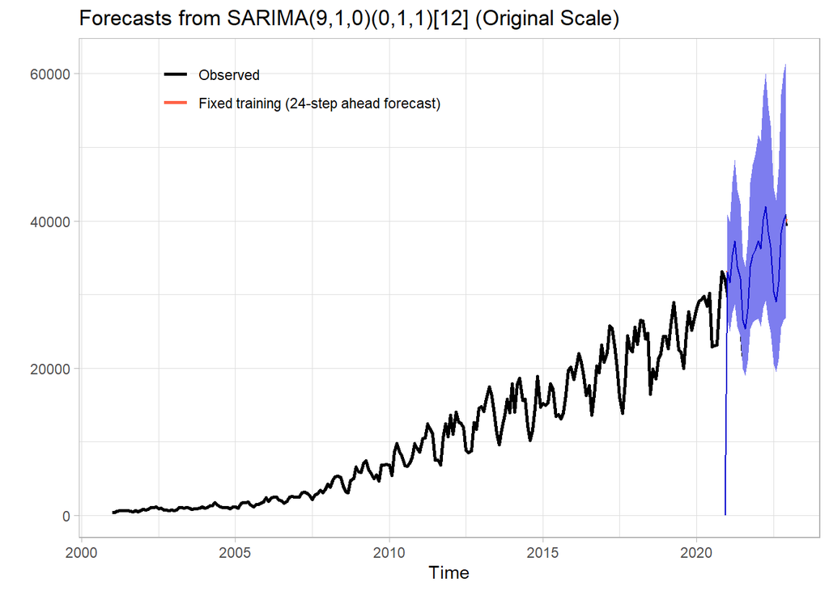

```r
# Reverter a transformação Box-Cox no forecast
M9.fct.v1_original_scale <- M9.fct.v1
M9.fct.v1_original_scale$mean <- InvBoxCox(M9.fct.v1$mean, lambda)

# Reverter a transformação nos limites inferior e superior (linha por linha/coluna)
M9.fct.v1_original_scale$lower <- apply(M9.fct.v1$lower, 2, InvBoxCox, lambda)
M9.fct.v1_original_scale$upper <- apply(M9.fct.v1$upper, 2, InvBoxCox, lambda)

# Criar o gráfico com a série observada e a previsão em escala original
autoplot(ts_c(Observed = ts_clean1,
              `Fixed training (24-step ahead forecast)` = M6.fct.v1_original_scale$mean),
         ylab = NULL, size = 1, main = "Forecasts from SARIMA(9,1,0)(0,1,1)[12] (Original Scale)") +
  scale_color_manual(values = c("black", "tomato")) +
  theme_light() +
  theme(legend.title = element_blank(),
        legend.background = element_blank(),
        legend.position = c(0.3, 0.9)) +
  autolayer(M9.fct.v1_original_scale, showgap = F)
```

*Organising the forecasts and checking the model accuracy.*

```r
# Criar a tabela de previsões para o modelo M9 na escala original
fct.tab_M9 <- data.frame(
  Month = as.yearmon(time(test_set)),
  Observed = as.numeric(test_set),
  Forecast = round(M9.fct.v1_original_scale$mean, 2),
  Error = round((as.numeric(test_set) - M9.fct.v1_original_scale$mean), 2),
  Error_PCT = scales::percent(
    (as.vector((as.numeric(test_set) - M9.fct.v1_original_scale$mean) / as.numeric(test_set))),
    accuracy = 0.01
  ),
  Covered_by_CI = dplyr::between(
    as.numeric(test_set),
    (M9.fct.v1_original_scale$lower),
    (M9.fct.v1_original_scale$upper)
  )
)

# Exibição da tabela
knitr::kable(fct.tab_M9, digits = 2, align = "lccccc", caption = "Forecasts (12-months ahead for Model M9)")
```

| Month | Observed | Forecast | Error | Error_PCT | Covered_by_CI |
| --- | --- | --- | --- | --- | --- |
| jan 2021 | 30060 | 33033.45 | -2973.45 | -9.89% | TRUE |
| fev 2021 | 26716 | 31627.84 | -4911.84 | -18.39% | TRUE |
| mar 2021 | 39205 | 35342.43 | 3862.57 | 9.85% | TRUE |
| abr 2021 | 36158 | 37260.55 | -1102.55 | -3.05% | TRUE |
| mai 2021 | 33787 | 33761.72 | 25.28 | 0.07% | TRUE |
| jun 2021 | 26672 | 32167.97 | -5495.97 | -20.61% | TRUE |
| jul 2021 | 21716 | 26482.30 | -4766.30 | -21.95% | TRUE |
| ago 2021 | 27071 | 25362.55 | 1708.45 | 6.31% | TRUE |
| set 2021 | 28998 | 28008.41 | 989.59 | 3.41% | TRUE |
| out 2021 | 32215 | 33876.25 | -1661.25 | -5.16% | TRUE |
| nov 2021 | 35751 | 35399.60 | 351.40 | 0.98% | TRUE |
| dez 2021 | 39849 | 36032.83 | 3816.17 | 9.58% | TRUE |
| jan 2022 | 38080 | 37274.09 | 805.91 | 2.12% | TRUE |
| fev 2022 | 37984 | 36178.97 | 1805.03 | 4.75% | TRUE |
| mar 2022 | 43014 | 40187.09 | 2826.91 | 6.57% | TRUE |
| abr 2022 | 45960 | 41973.35 | 3986.65 | 8.67% | TRUE |
| mai 2022 | 41668 | 38542.56 | 3125.44 | 7.50% | TRUE |
| jun 2022 | 33483 | 36429.41 | -2946.41 | -8.80% | TRUE |
| jul 2022 | 29302 | 30319.51 | -1017.51 | -3.47% | TRUE |
| ago 2022 | 24355 | 28966.59 | -4611.59 | -18.93% | TRUE |
| set 2022 | 27032 | 31647.11 | -4615.11 | -17.07% | TRUE |
| out 2022 | 32824 | 38395.61 | -5571.61 | -16.97% | TRUE |
| nov 2022 | 41826 | 40061.24 | 1764.76 | 4.22% | TRUE |
| dez 2022 | 39282 | 40861.86 | -1579.86 | -4.02% | TRUE |

```r
# Accuracy Measures M9
accuracy_M9 <- rbind(accuracy(M9.fct.v1_original_scale$mean, test_set))
rownames(accuracy_M9) <- c("Fixed training (12-step ahead forecast)")

knitr::kable(accuracy_M9, digits = 4, align = "ccccccc", caption = "Accuracy measures (12-step ahead forecast) M9")
```

[output not shown]

## 4.2 Forecasting 24 months with 1-step ahead - Interaction

- This forecasting strategy assumes that we know the new data at the time of forecasting, rather than fitting a new model based on new data.
- Forecasting uses the fitted model to predict the new data.

*Plotting the forecasts for M4*

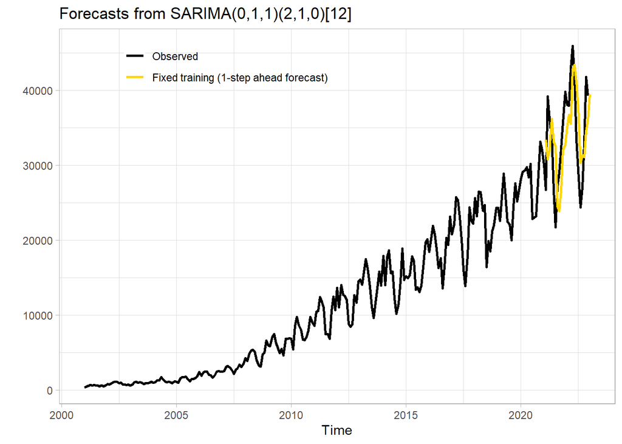

```r
# converting the ts object into a DF
ts_clean1_boxcox <- BoxCox(ts_clean1, lambda)
ts_df = ts_df(ts_clean1_boxcox)

# forecasting 24 times 1-step ahead for M4
output = data.frame()
for (i in 1:24) {
  df_select = ts_df %>%
    filter(time <= as.Date("2020-12-01") %m+% months(i))

  ts_select = ts(df_select$value, freq = 12, end = c(year(tail(df_select$time,
                                                               1)), month(tail(df_select$time, 1))))

  fit = Arima(ts_select, model = M4.fit_plots)

  aux = bind_cols(time = as.Date("2021-01-01") %m+% months(i), value = tail(fitted(fit),
                                                                            1))

  output = bind_rows(output, aux)
}

# converting output to TS
M4.fct.v2 = ts_ts(output)
M4.fct.v2_original_scale <- M4.fct.v2
M4.fct.v2_original_scale <- InvBoxCox(M4.fct.v2_original_scale, lambda)

# forecasts plot
autoplot(ts_c(Observed = ts_clean1, `Fixed training (1-step ahead forecast)` = M4.fct.v2_original_scale),
         ylab = NULL, size = 1, main = "Forecasts from SARIMA(0,1,1)(2,1,0)[12]") + scale_color_manual(values = c("black",
                                                                                                                 "gold")) + theme_light() + theme(legend.title = element_blank(), legend.background = element_blank(),
                                                                                                                                                  legend.position = c(0.3, 0.9))
```

*Plotting the forecasts for M6*

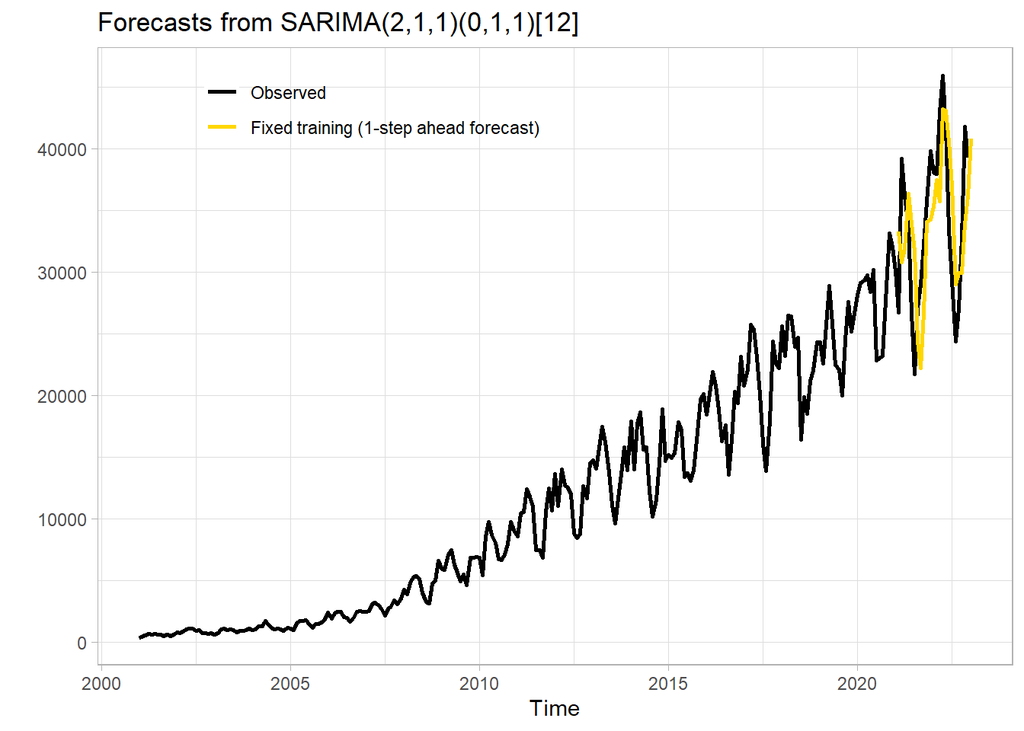

```r
# forecasting 24 times 1-step ahead for M6
output = data.frame()
for (i in 1:24) {
  df_select = ts_df %>%
    filter(time <= as.Date("2020-12-01") %m+% months(i))

  ts_select = ts(df_select$value, freq = 12, end = c(year(tail(df_select$time,
                                                               1)), month(tail(df_select$time, 1))))

  fit = Arima(ts_select, model = M6.fit_plots)

  aux = bind_cols(time = as.Date("2021-01-01") %m+% months(i), value = tail(fitted(fit),
                                                                            1))

  output = bind_rows(output, aux)
}

# converting output to TS
M6.fct.v2 = ts_ts(output)
M6.fct.v2_original_scale <- M6.fct.v2
M6.fct.v2_original_scale <- InvBoxCox(M6.fct.v2_original_scale, lambda)

# forecasts plot
autoplot(ts_c(Observed = ts_clean1, `Fixed training (1-step ahead forecast)` = M6.fct.v2_original_scale),
         ylab = NULL, size = 1, main = "Forecasts from SARIMA(2,1,1)(0,1,1)[12]") + scale_color_manual(values = c("black",
                                                                                                                 "gold")) + theme_light() + theme(legend.title = element_blank(), legend.background = element_blank(),
                                                                                                                                                  legend.position = c(0.3, 0.9))
```

*Plotting the forecasts for M9*

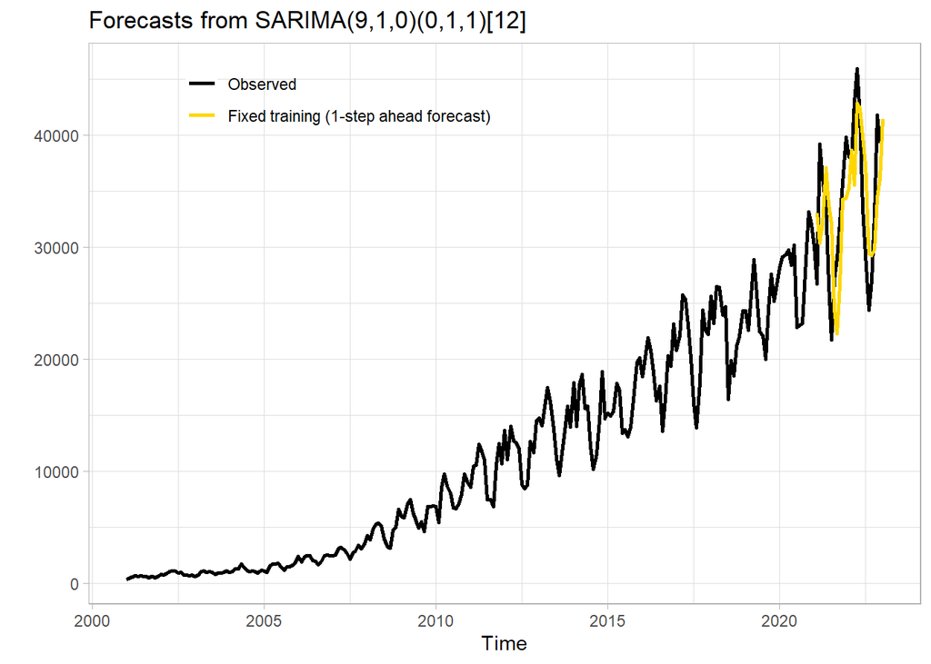

```r
# forecasting 24 times 1-step ahead for M9
output = data.frame()
for (i in 1:24) {
  df_select = ts_df %>%
    filter(time <= as.Date("2020-12-01") %m+% months(i))

  ts_select = ts(df_select$value, freq = 12, end = c(year(tail(df_select$time,
                                                               1)), month(tail(df_select$time, 1))))

  fit = Arima(ts_select, model = M9.fit_plots)

  aux = bind_cols(time = as.Date("2021-01-01") %m+% months(i), value = tail(fitted(fit),
                                                                            1))

  output = bind_rows(output, aux)
}

# converting output to TS
M9.fct.v2 = ts_ts(output)
M9.fct.v2_original_scale <- M9.fct.v2
M9.fct.v2_original_scale <- InvBoxCox(M9.fct.v2_original_scale, lambda)

# forecasts plot
autoplot(ts_c(Observed = ts_clean1, `Fixed training (1-step ahead forecast)` = M9.fct.v2_original_scale),
         ylab = NULL, size = 1, main = "Forecasts from SARIMA(9,1,0)(0,1,1)[12]") + scale_color_manual(values = c("black",
                                                                                                                 "gold")) + theme_light() + theme(legend.title = element_blank(), legend.background = element_blank(),
                                                                                                                                                  legend.position = c(0.3, 0.9))
```

## 4.3 Forecasting 24 months with 1-step ahead - Expanding windows

- In the expanding window strategy, the training sample size is sequentially increased by one time unit.
- The forecasts generated are based on multiple fitting models.

*Plotting the forecasts for M4*

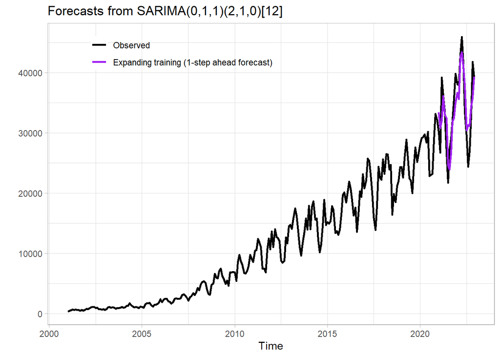

```r
# converting the ts object into a DF
ts_df = ts_df(ts_clean1_boxcox)

# forecasting M1 specification with expanding windows
output = data.frame()
for (i in 0:23) {
  df_select = ts_df %>%
    filter(time <= as.Date("2020-12-01") %m+% months(i))

  ts_select = ts(df_select$value, freq = 12, end = c(year(tail(df_select$time,
                                                               1)), month(tail(df_select$time, 1))))

  fit = Arima(ts_select, order = c(0, 1, 1), seasonal = c(2, 1, 0))

  M4.fct.expw = forecast(fit, h = 1, level = 95)

  aux = bind_cols(time = as.Date("2021-01-01") %m+% months(i), model_specification = as.character(fit),
                  value = M4.fct.expw$mean)

  output = bind_rows(output, aux)
}

# converting output to TS
M4.fct.v3 = ts_ts(output)
M4.fct.v3_original_scale <- M4.fct.v3
M4.fct.v3_original_scale <- InvBoxCox(M4.fct.v3_original_scale, lambda)

# forecasts plot
autoplot(ts_c(Observed = ts_clean1, `Expanding training (1-step ahead forecast)` = M4.fct.v3_original_scale),
         ylab = NULL, size = 1, main = "Forecasts from SARIMA(0,1,1)(2,1,0)[12]") + scale_color_manual(values = c("black",
                                                                                                                 "purple")) + theme_light() + theme(legend.title = element_blank(), legend.background = element_blank(),legend.position = c(0.3, 0.9))
```

*Plotting the forecasts for M6*

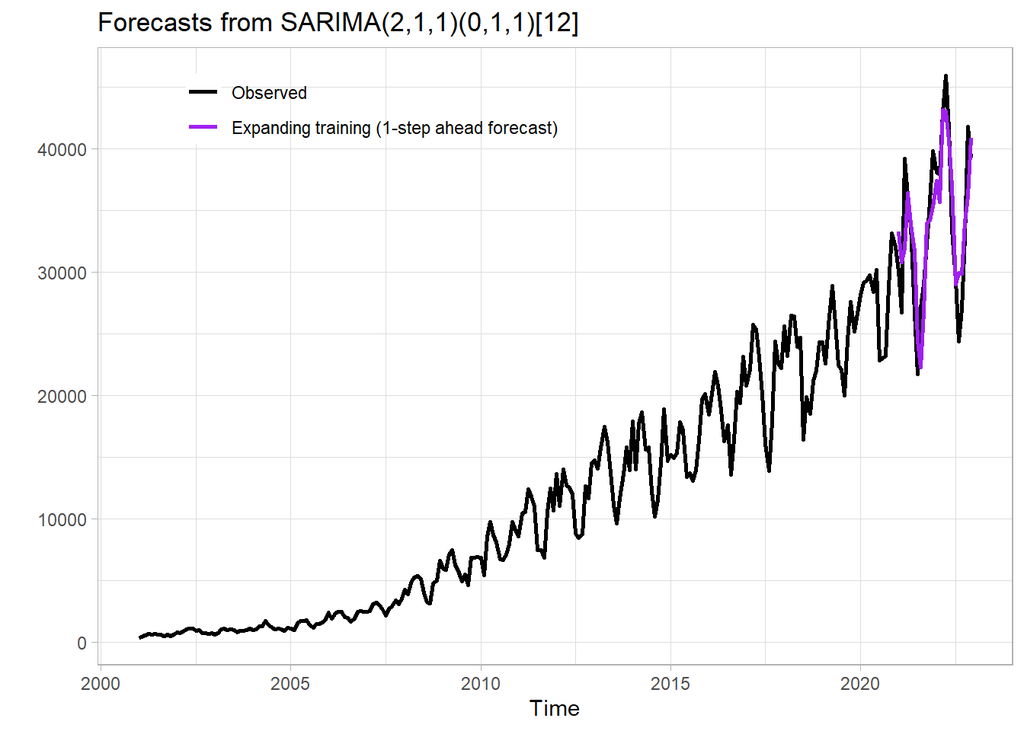

```r
# forecasting M1 specification with expanding windows
output = data.frame()
for (i in 0:23) {
  df_select = ts_df %>%
    filter(time <= as.Date("2020-12-01") %m+% months(i))

  ts_select = ts(df_select$value, freq = 12, end = c(year(tail(df_select$time,
                                                               1)), month(tail(df_select$time, 1))))

  fit = Arima(ts_select, order = c(2, 1, 1), seasonal = c(0, 1, 1))

  M6.fct.expw = forecast(fit, h = 1, level = 95)

  aux = bind_cols(time = as.Date("2021-01-01") %m+% months(i), model_specification = as.character(fit),
                  value = M6.fct.expw$mean)

  output = bind_rows(output, aux)
}

# converting output to TS
M6.fct.v3 = ts_ts(output)
M6.fct.v3_original_scale <- M6.fct.v3
M6.fct.v3_original_scale <- InvBoxCox(M6.fct.v3_original_scale, lambda)

# forecasts plot
autoplot(ts_c(Observed = ts_clean1, `Expanding training (1-step ahead forecast)` = M6.fct.v3_original_scale),
         ylab = NULL, size = 1, main = "Forecasts from SARIMA(2,1,1)(0,1,1)[12]") + scale_color_manual(values = c("black",
                                                                                                                 "purple")) + theme_light() + theme(legend.title = element_blank(), legend.background = element_blank(),
                                                                                                                                                    legend.position = c(0.3, 0.9))
```

*Plotting the forecasts for M9*

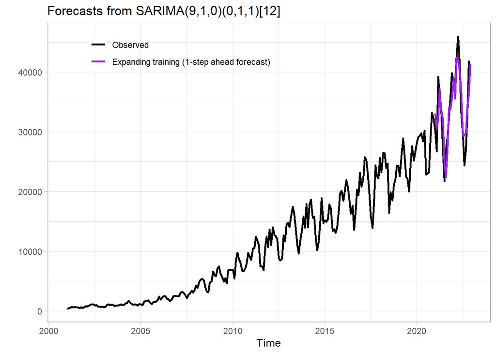

```r
# forecasting M1 specification with expanding windows
output = data.frame()
for (i in 0:23) {
  df_select = ts_df %>%
    filter(time <= as.Date("2020-12-01") %m+% months(i))

  ts_select = ts(df_select$value, freq = 12, end = c(year(tail(df_select$time,
                                                               1)), month(tail(df_select$time, 1))))

  fit = Arima(ts_select, order = c(9, 1, 0), seasonal = c(0, 1, 1))

  M9.fct.expw = forecast(fit, h = 1, level = 95)

  aux = bind_cols(time = as.Date("2021-01-01") %m+% months(i), model_specification = as.character(fit),
                  value = M9.fct.expw$mean)

  output = bind_rows(output, aux)
}

# converting output to TS
M9.fct.v3 = ts_ts(output)
M9.fct.v3_original_scale <- M9.fct.v3
M9.fct.v3_original_scale <- InvBoxCox(M9.fct.v3_original_scale, lambda)

# forecasts plot
autoplot(ts_c(Observed = ts_clean1, `Expanding training (1-step ahead forecast)` = M9.fct.v3_original_scale),
         ylab = NULL, size = 1, main = "Forecasts from SARIMA(9,1,0)(0,1,1)[12]") + scale_color_manual(values = c("black",
                                                                                                                 "purple")) + theme_light() + theme(legend.title = element_blank(), legend.background = element_blank(),
                                                                                                                                                    legend.position=c(0.3,0.9))
```

## 4.4 Forecasting 24 Months with 1-Step Ahead - Recursive Windows

- In the recursive window strategy, the training sample size remains fixed during the forecast generation.
- However, at each step, the set of observations in the training sample is updated.
- The training window shifts by one time unit to produce a new forecast.
- Forecasts are generated based on multiple models fitted throughout the process.

M4

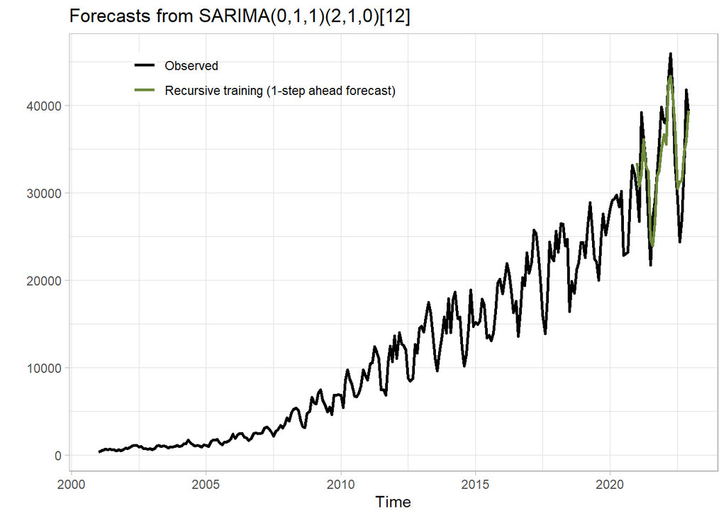

```r
ts_df = ts_df(ts_clean1_boxcox)

output = data.frame()
for (i in 0:23) {
  df_select = ts_df %>%
    filter(time >= as.Date("2000-01-01") %m+% months(i) & time <= as.Date("2020-12-01") %m+% months(i))

  ts_select = ts(df_select$value, freq = 12, end = c(year(tail(df_select$time, 1)), month(tail(df_select$time, 1))))

  fit = Arima(ts_select, order = c(0, 1, 1), seasonal = c(2, 1, 0))

  M4.fct.recw = forecast(fit, h = 1, level = 95)

  aux = bind_cols(time = as.Date("2021-01-01") %m+% months(i), model_specification = as.character(fit), value = M4.fct.recw$mean)

  output = bind_rows(output, aux)
}

# Converting output to TS
M4.fct.v4 = ts_ts(output)
M4.fct.v4_original_scale <- M4.fct.v4
M4.fct.v4_original_scale <- InvBoxCox(M4.fct.v4_original_scale, lambda)

# Forecasts plot
autoplot(ts_c(Observed = ts_clean1, `Recursive training (1-step ahead forecast)` = M4.fct.v4_original_scale),
         ylab = NULL, size = 1, main = "Forecasts from SARIMA(0,1,1)(2,1,0)[12]") +
  scale_color_manual(values = c("black", "darkolivegreen4")) +
  theme_light() +
  theme(legend.title = element_blank(), legend.background = element_blank(), legend.position = c(0.3, 0.9))
```

M6

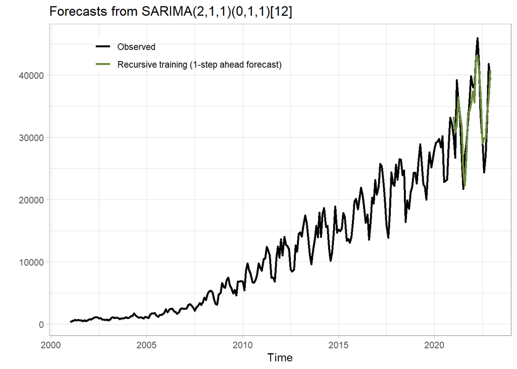

```r
output = data.frame()
for (i in 0:23) {
  df_select = ts_df %>%
    filter(time >= as.Date("2000-01-01") %m+% months(i) & time <= as.Date("2020-12-01") %m+% months(i))

  ts_select = ts(df_select$value, freq = 12, end = c(year(tail(df_select$time, 1)), month(tail(df_select$time, 1))))

  fit = Arima(ts_select, order = c(2, 1, 1), seasonal = c(0, 1, 1))

  M6.fct.recw = forecast(fit, h = 1, level = 95)

  aux = bind_cols(time = as.Date("2021-01-01") %m+% months(i), model_specification = as.character(fit), value = M6.fct.recw$mean)

  output = bind_rows(output, aux)
}

# Converting output to TS
M6.fct.v4 = ts_ts(output)
M6.fct.v4_original_scale <- M6.fct.v4
M6.fct.v4_original_scale <- InvBoxCox(M6.fct.v4_original_scale, lambda)

# Forecasts plot
autoplot(ts_c(Observed = ts_clean1, `Recursive training (1-step ahead forecast)` = M6.fct.v4_original_scale),
         ylab = NULL, size = 1, main = "Forecasts from SARIMA(2,1,1)(0,1,1)[12]") +
  scale_color_manual(values = c("black", "darkolivegreen4")) +
  theme_light() +
  theme(legend.title = element_blank(), legend.background = element_blank(), legend.position = c(0.3, 0.9))
```

M9

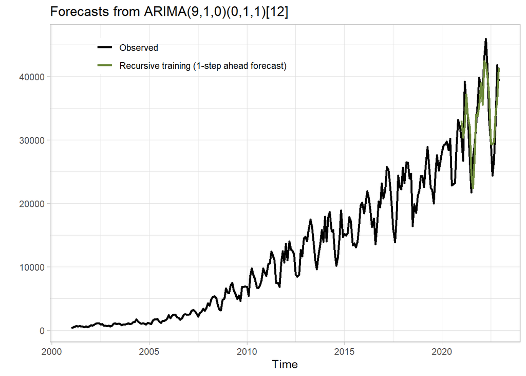

```r
output = data.frame()
for (i in 0:23) {
  df_select = ts_df %>%
    filter(time >= as.Date("2000-01-01") %m+% months(i) & time <= as.Date("2020-12-01") %m+% months(i))

  ts_select = ts(df_select$value, freq = 12, end = c(year(tail(df_select$time, 1)), month(tail(df_select$time, 1))))

  fit = Arima(ts_select, order = c(9, 1, 0), seasonal = c(0, 1, 1))

  M9.fct.recw = forecast(fit, h = 1, level = 95)

  aux = bind_cols(time = as.Date("2021-01-01") %m+% months(i), model_specification = as.character(fit), value = M9.fct.recw$mean)

  output = bind_rows(output, aux)
}

# Converting output to TS
M9.fct.v4 = ts_ts(output)
M9.fct.v4_original_scale <- M9.fct.v4
M9.fct.v4_original_scale <- InvBoxCox(M9.fct.v4_original_scale, lambda)

autoplot(ts_c(Observed = ts_clean1, `Recursive training (1-step ahead forecast)` = M9.fct.v4_original_scale),
         ylab = NULL, size = 1, main = "Forecasts from ARIMA(9,1,0)(0,1,1)[12]") +
  scale_color_manual(values = c("black", "darkolivegreen4")) +
  theme_light() +
  theme(legend.title = element_blank(), legend.background = element_blank(), legend.position = c(0.3, 0.9))
```

**Combined Forecasts**

M4

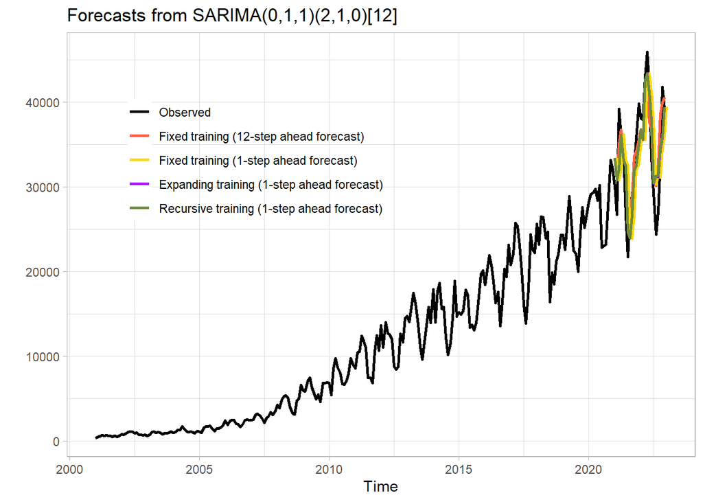

```r
autoplot(ts_c(Observed = ts_clean1, `Fixed training (12-step ahead forecast)` = M4.fct.v1_original_scale$mean,
    `Fixed training (1-step ahead forecast)` = M4.fct.v2_original_scale, `Expanding training (1-step ahead forecast)` = M4.fct.v3_original_scale,
    `Recursive training (1-step ahead forecast)` = M4.fct.v4_original_scale), ylab = NULL, size = 1,
    main = "Forecasts from SARIMA(0,1,1)(2,1,0)[12]") + scale_color_manual(values = c("black",
    "tomato", "gold", "purple", "darkolivegreen4")) + theme_light() + theme(legend.title = element_blank(),
    legend.background = element_blank(), legend.position = c(0.3, 0.7))
```

M6

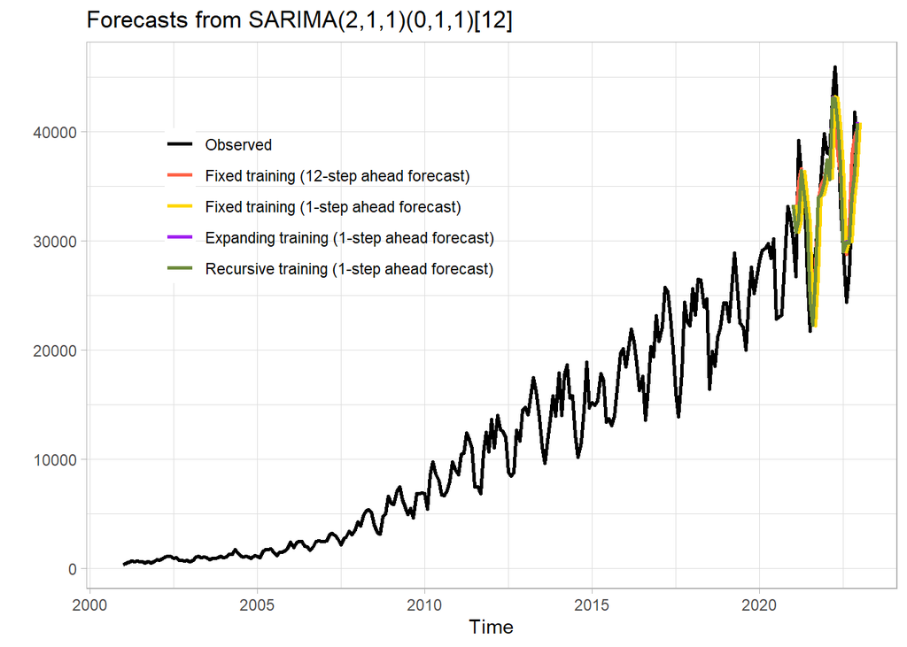

```r
autoplot(ts_c(Observed = ts_clean1, `Fixed training (12-step ahead forecast)` = M6.fct.v1_original_scale$mean,
    `Fixed training (1-step ahead forecast)` = M6.fct.v2_original_scale, `Expanding training (1-step ahead forecast)` = M6.fct.v3_original_scale,
    `Recursive training (1-step ahead forecast)` = M6.fct.v4_original_scale), ylab = NULL, size = 1,
    main = "Forecasts from SARIMA(2,1,1)(0,1,1)[12]") + scale_color_manual(values = c("black",
    "tomato", "gold", "purple", "darkolivegreen4")) + theme_light() + theme(legend.title = element_blank(),
    legend.background = element_blank(), legend.position = c(0.3, 0.7))
```

M9

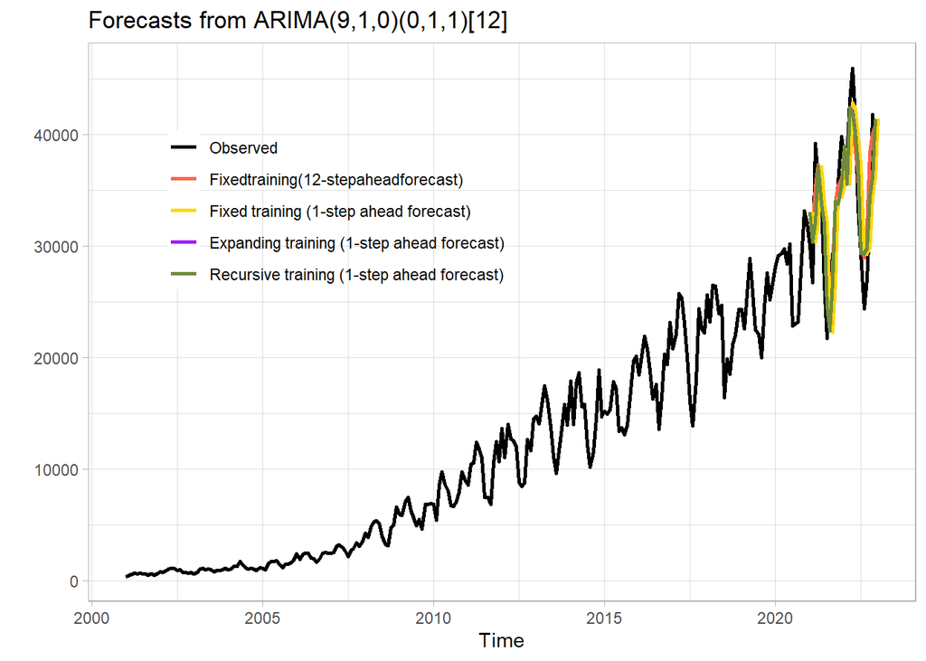

```r
autoplot(ts_c(Observed = ts_clean1,     `Fixedtraining(12-stepaheadforecast)`=M9.fct.v1_original_scale$mean,
`Fixed training (1-step ahead forecast)` = M9.fct.v2_original_scale,
`Expanding training (1-step ahead forecast)` = M9.fct.v3_original_scale,
`Recursive training (1-step ahead forecast)` = M9.fct.v4_original_scale), ylab = NULL, size = 1,
    main = "Forecasts from ARIMA(9,1,0)(0,1,1)[12]") + scale_color_manual(values = c("black",
    "tomato", "gold", "purple", "darkolivegreen4")) + theme_light() + theme(legend.title = element_blank(),
    legend.background = element_blank(), legend.position = c(0.3, 0.7))
```

# 5 Assessing the quality of produced forecasts

**Plotting the forecasts errors**

M4

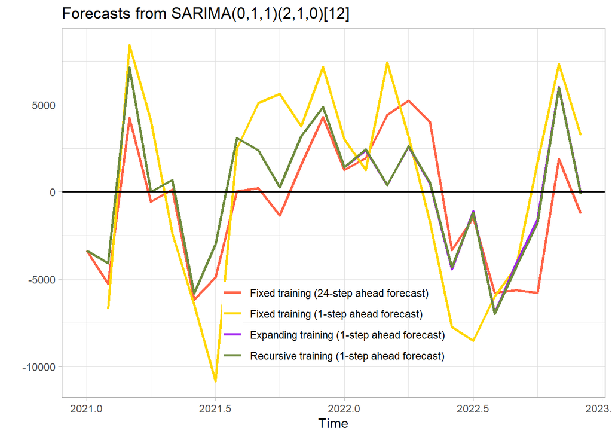

```r
autoplot(ts_c(`Fixed training (24-step ahead forecast)` = test_set - M4.fct.v1_original_scale$mean,
              `Fixed training (1-step ahead forecast)` = test_set - M4.fct.v2_original_scale, `Expanding training (1-step ahead forecast)` = test_set - M4.fct.v3_original_scale, `Recursive training (1-step ahead forecast)` = test_set - M4.fct.v4_original_scale),
         ylab = NULL, size = 1, main = "Forecasts from SARIMA(0,1,1)(2,1,0)[12]") + scale_color_manual(values = c("tomato","gold", "purple", "darkolivegreen4")) + theme_light() + theme(legend.title = element_blank(),
                                                                                                                                                                               legend.background = element_blank(), legend.position = c(0.5, 0.2)) + geom_hline(yintercept = 0,
color = "black", size = 1)
```

M6

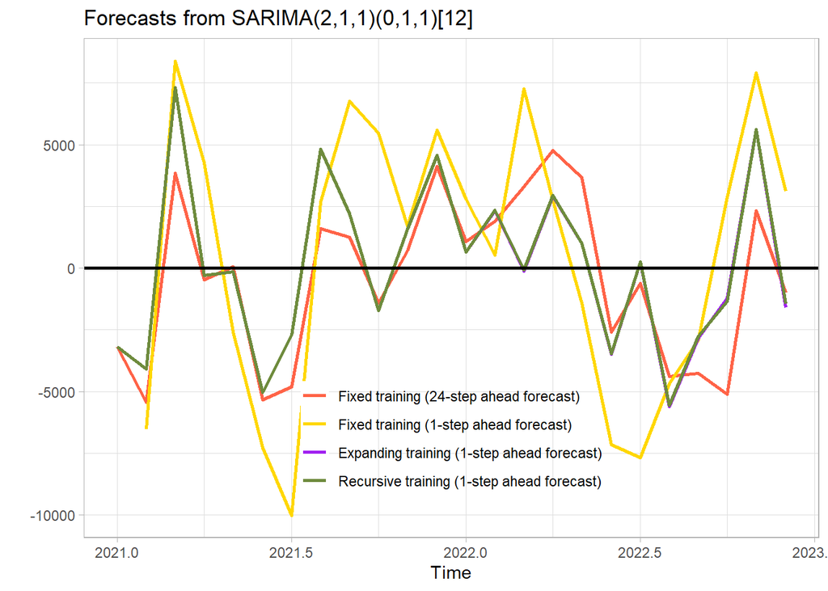

```r
autoplot(ts_c(`Fixed training (24-step ahead forecast)` = test_set - M6.fct.v1_original_scale$mean,
              `Fixed training (1-step ahead forecast)` = test_set - M6.fct.v2_original_scale, `Expanding training (1-step ahead forecast)` = test_set -
                M6.fct.v3_original_scale, `Recursive training (1-step ahead forecast)` = test_set - M6.fct.v4_original_scale),
         ylab = NULL, size = 1, main = "Forecasts from SARIMA(2,1,1)(0,1,1)[12]") + scale_color_manual(values = c("tomato",
                                                                                                                 "gold", "purple", "darkolivegreen4")) + theme_light() + theme(legend.title = element_blank(),
                                                                                                                                                                               legend.background = element_blank(), legend.position = c(0.5, 0.2)) + geom_hline(yintercept = 0,
                                                                                                                                                                                                                                                                color = "black", size = 1)
```

M9

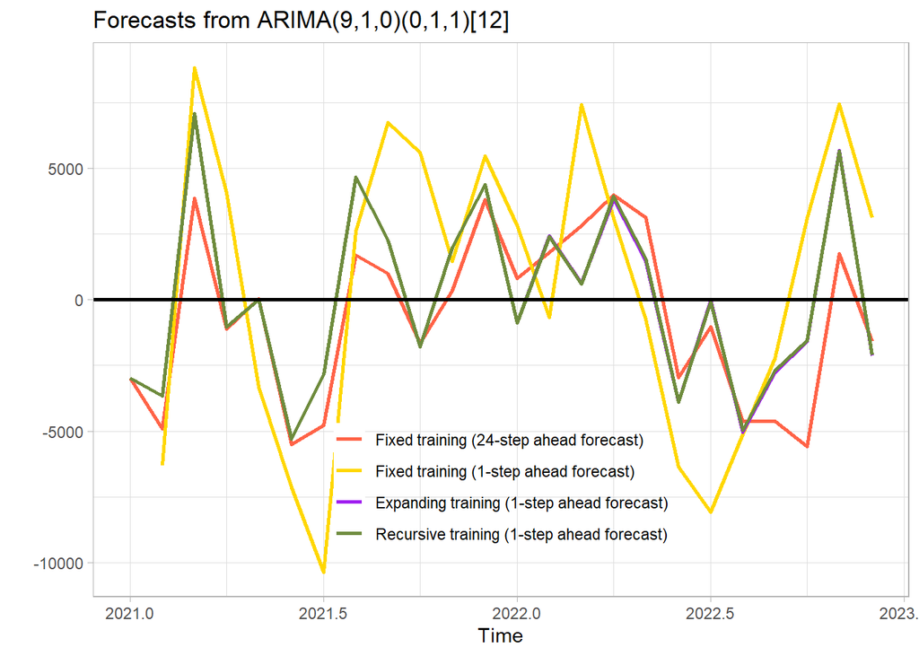

```r
autoplot(ts_c(`Fixed training (24-step ahead forecast)` = test_set - M9.fct.v1_original_scale$mean,
              `Fixed training (1-step ahead forecast)` = test_set - M9.fct.v2_original_scale, `Expanding training (1-step ahead forecast)` = test_set -
                M9.fct.v3_original_scale, `Recursive training (1-step ahead forecast)` = test_set - M9.fct.v4_original_scale),
         ylab = NULL, size = 1, main = "Forecasts from ARIMA(9,1,0)(0,1,1)[12]") + scale_color_manual(values = c("tomato",
                                                                                                                 "gold", "purple", "darkolivegreen4")) + theme_light() + theme(legend.title = element_blank(),
                                                                                                                                                                               legend.background = element_blank(), legend.position = c(0.5, 0.2)) + geom_hline(yintercept = 0,
                                                                                                                                                                                                                                                                color = "black", size = 1)
```

Accuracy Measures M4